# HBCU Enrollment

Jo Hardin

2/2/2021

### The Data

The data this week comes from [Data.World](https://data.world/nces/hbcu-fall-enrollment-1976-2015) and [Data.World](https://data.world/nces/high-school-completion-and-bachelors-degree-attainment) and was originally from the [NCES](https://data.world/nces).

The datasets describe different subsets of students: high school, bachelor’s degree, and HBCU. I’m not 100% sure how each group is defined (e.g., are there graduate students included in the HBCU group?). But let’s look at the HBCU enrollment data in more detail.

```r
hbcu_all <- readr::read_csv("hbcu_all.csv")
hbcu_black <- readr::read_csv("hbcu_black.csv")
names(hbcu_all)
```

```
##  [1] "Year"             "Total enrollment" "Males"            "Females"
##  [5] "4-year"           "2-year"           "Total - Public"   "4-year - Public"
##  [9] "2-year - Public"  "Total - Private"  "4-year - Private" "2-year - Private"
```

The main tidying for the dataset is to create a few long columns instead of the current wide data. I looked at the different columns and thought about which variables we could create. I came up with the following list of new columns that I’d like to have:

- year
- enrollment
- 2 vs 4 vs total
- public vs private vs total
- gender

I found the following help in [advanced pivoting](https://dcl-wrangle.stanford.edu/pivot_advanced.html), and realized that if I changed the name of the variables, they would be in a format that would make it easy to use `pivot_longer()` quite directly. Note that the majority of the columns don’t have any gender information (that is, gender is combined into one column), so I indicate the combined gender information with “X”.

```r
names(hbcu_all) <- c("year", "total_all_X", "total_all_M", "total_all_F",
                     "4yr_all_X", "2yr_all_X", "total_public_X", "4yr_public_X", "2yr_public_X",
                     "total_private_X", "4yr_private_X", "2yr_private_X")

names(hbcu_black) <- c("year", "total_all_X", "total_all_M", "total_all_F",
                     "4yr_all_X", "2yr_all_X", "total_public_X", "4yr_public_X", "2yr_public_X",
                     "total_private_X", "4yr_private_X", "2yr_private_X")


hbcu <- hbcu_all %>%
  pivot_longer(
    cols = -year,
    names_to = c("degree", "funding", "gender"),
    names_sep = "_",
    values_to = "enrollment"
  ) %>%
  mutate(race = "all")

hbcuB <- hbcu_black %>%
    pivot_longer(
    cols = -year,
    names_to = c("degree", "funding", "gender"),
    names_sep = "_",
    values_to = "enrollment"
  ) %>%
  mutate(race = "Black")


hbcu_full <- rbind(hbcu, hbcuB)
```

#### Visualize changes in enrollment

```r
#devtools::install_github("ciannabp/inauguration")
library(inauguration)
#inauguration("inauguration_2021_bernie")
```

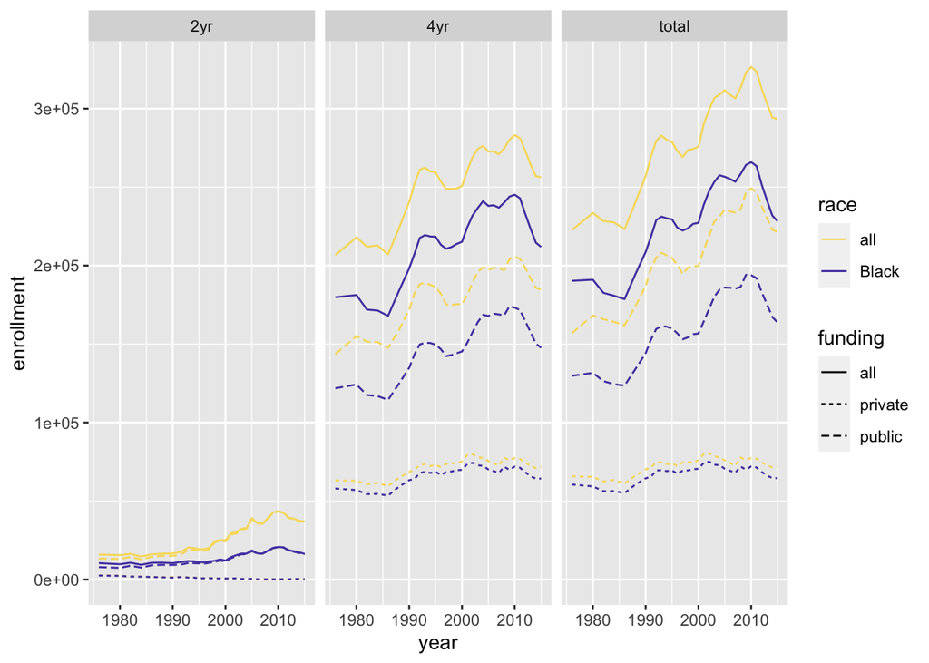

```r
hbcu_full %>%
  filter(gender == "X") %>%
  ggplot(aes(x = year, y = enrollment, color = race,
             group = interaction(degree, funding, race), linetype = funding)) +
  geom_line() +
  facet_wrap(~degree) +
  scale_color_manual(values = inauguration("inauguration_2021")[c(6,1)])
```

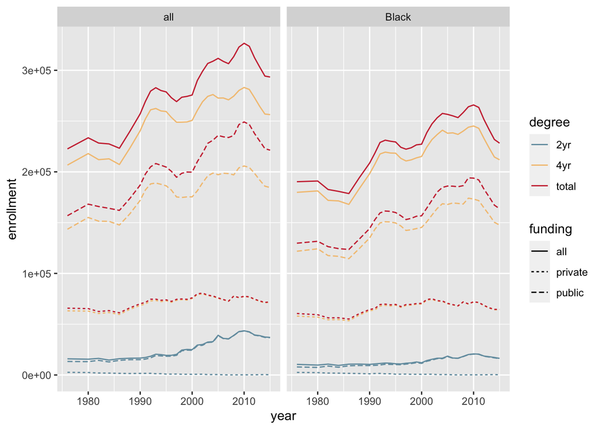

```r
hbcu_full %>%
  filter(gender == "X") %>%
  ggplot(aes(x = year, y = enrollment, color = degree,
             group = interaction(degree, funding, race), linetype = funding)) +
  geom_line() +
  facet_wrap(~race) +
  scale_color_manual(values = inauguration("inauguration_2021")[c(2,3,5)])
```

#### Important Closing

```r
praise()
```

```
## [1] "You are remarkable!"
```